# Laboratorio 4: "Diagramas de ojo e Interferencia entre símbolos"

### Punto 3: variación del span para $\beta = 0.25$

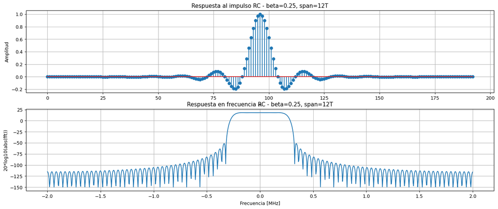

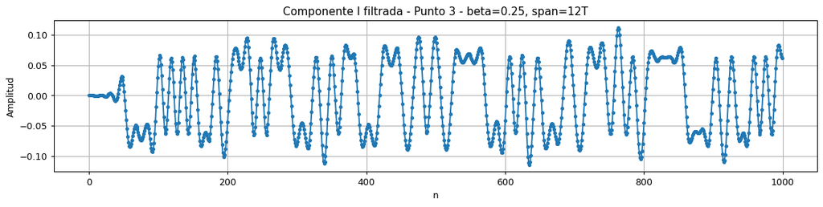

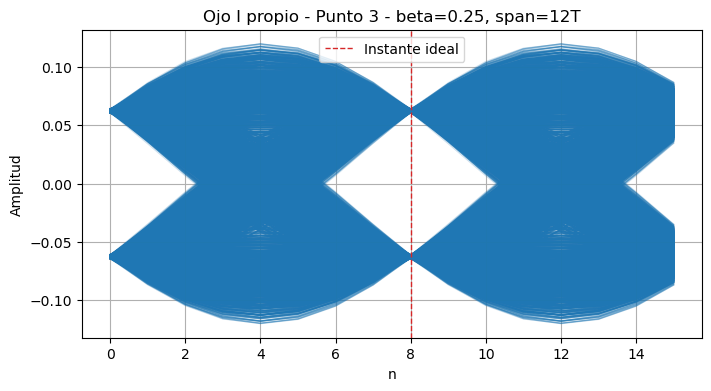

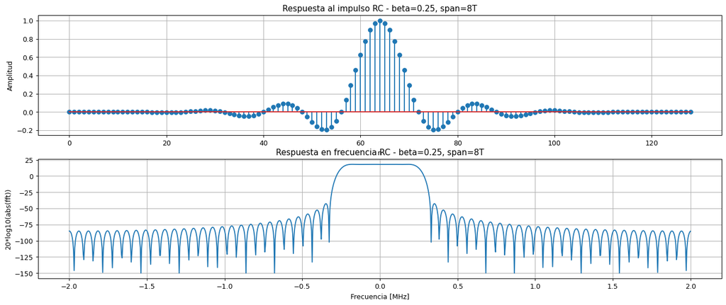

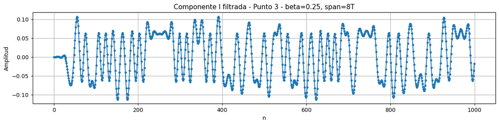

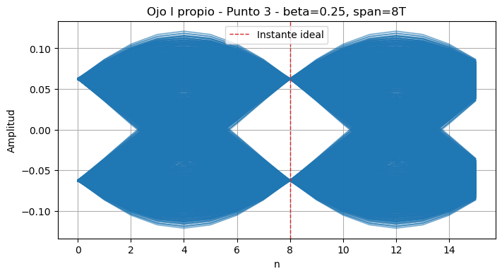

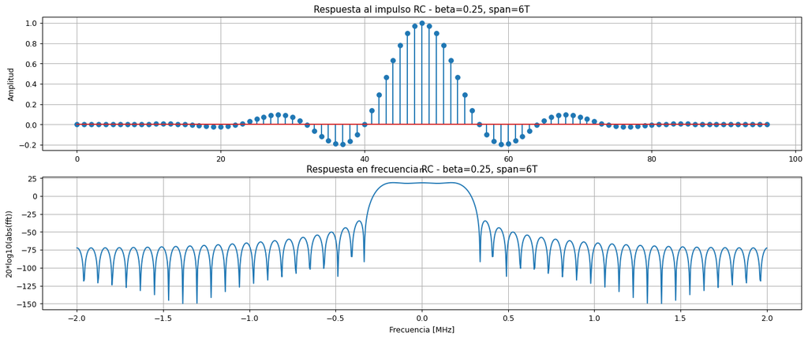

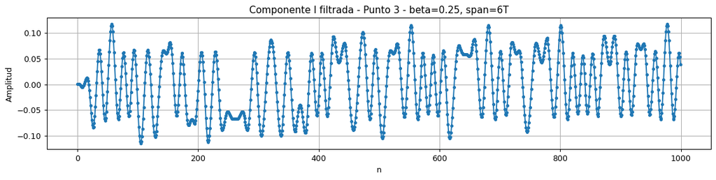

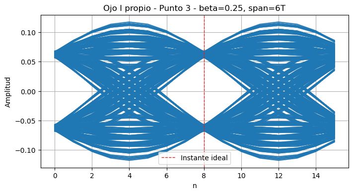

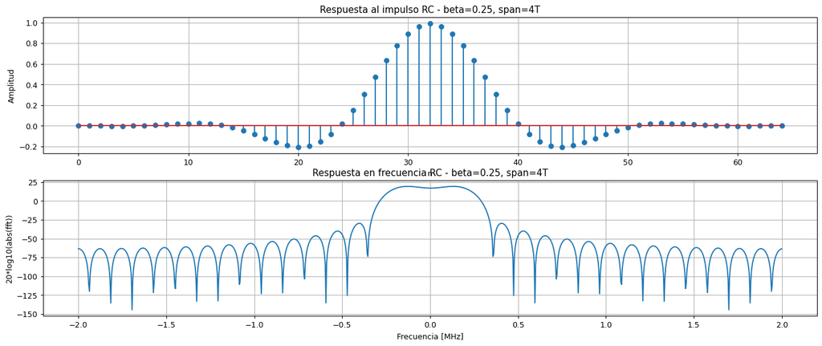

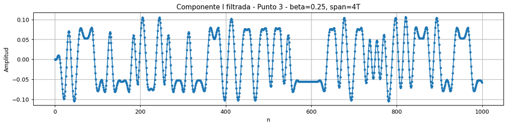

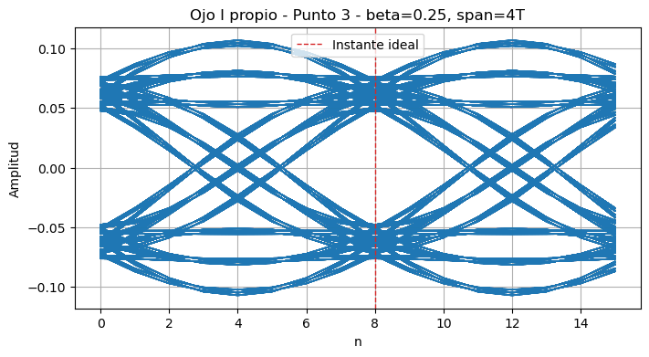

```python
# Punto 3: beta = 0.25 y truncamientos de 12T, 8T, 6T y 4T

resultados_span = {}
for span_case in [12, 8, 6, 4]:
    plot_filter_case(beta_case=0.25, span_case=span_case)
    resultados_span[span_case] = run_sdr_eye_case(
        beta_case=0.25,
        span_case=span_case,
        loopback_case=1,
        tx_atten_case=-30,
        title=f"Punto 3 - beta=0.25, span={span_case}T",
        use_custom_eye=True,
        seed=1234,
    )
```

### Punto 4: loopback desactivado

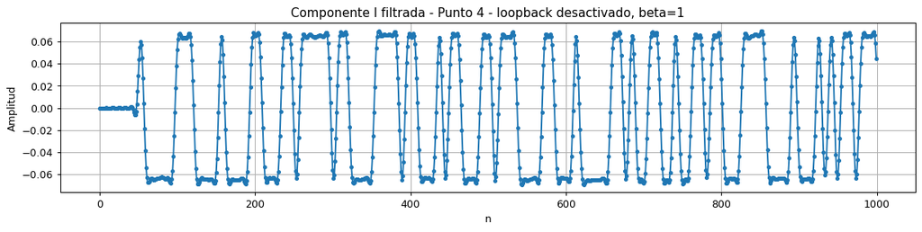

[figure not shown]

```python
# Punto 4: loopback desactivado, señal sale e ingresa por antena
# Si el ojo no sale claro en el primer intento, repetir esta celda.

resultado_antena = run_sdr_eye_case(
    beta_case=1,
    span_case=12,
    loopback_case=0,
    tx_atten_case=-30,
    title="Punto 4 - loopback desactivado, beta=1",
    use_custom_eye=True,
    seed=1234,
)
```

### Punto 5: reducción de SNR con loopback RF

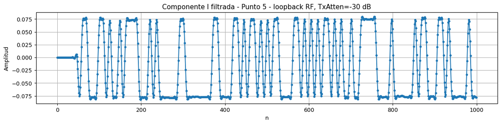

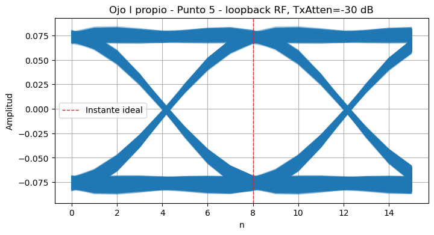

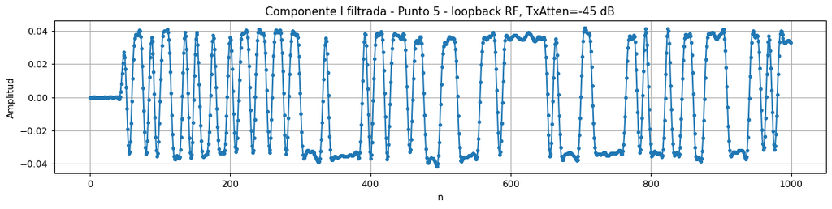

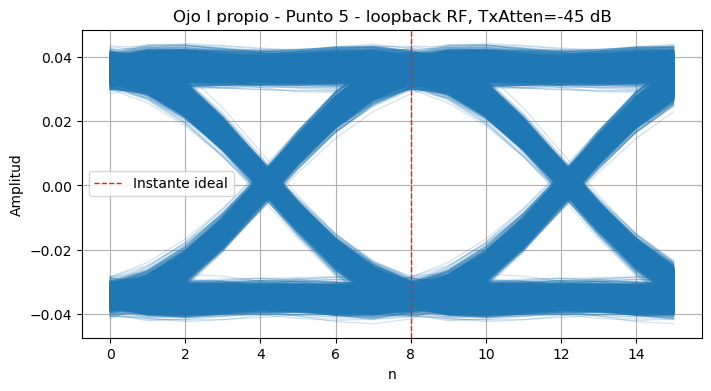

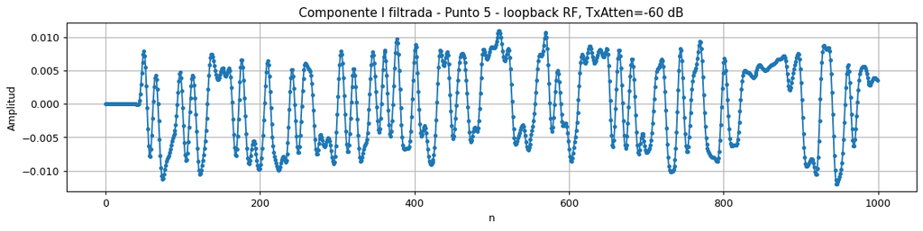

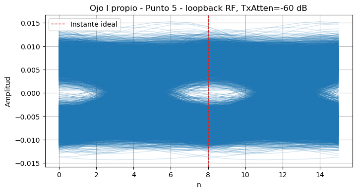

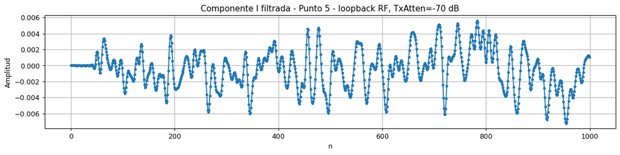

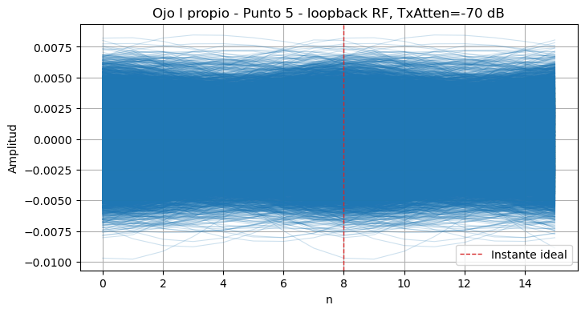

```python
# Punto 5: loopback RF y reducción de SNR variando TxAtten
# A medida que TxAtten es más negativo, baja la potencia transmitida.

resultados_txatten = {}
for tx_atten_case in [-30, -45, -60, -70]:
    resultados_txatten[tx_atten_case] = run_sdr_eye_case(
        beta_case=1,
        span_case=12,
        loopback_case=2,
        tx_atten_case=tx_atten_case,
        title=f"Punto 5 - loopback RF, TxAtten={tx_atten_case} dB",
        use_custom_eye=True,
        seed=1234,
    )
```

## Respuestas consolidadas

### 1. Influencia de $\beta$ con loopback digital

Al disminuir $\beta$ desde 1 hasta 0.25, la respuesta al impulso del filtro coseno realzado se vuelve más extendida temporalmente: aparecen colas más largas y más oscilaciones laterales. Con $\beta$ grande, el pulso decae más rápido; con $\beta$ pequeño, el pulso se parece más al caso ideal de ancho de banda mínimo, que necesita mayor extensión temporal.

En frecuencia ocurre lo complementario: al disminuir $\beta$, se reduce el exceso de ancho de banda y la respuesta se angosta hacia el mínimo de Nyquist. Como el ruido blanco tiene densidad espectral aproximadamente constante, al ocupar menor ancho de banda ingresa menos potencia de ruido al receptor. Por eso, desde el punto de vista de potencia de ruido integrada, el sistema es más inmune al AWGN para $\beta$ más pequeño. La contracara es que se vuelve más exigente frente a errores de sincronismo.

Para $\beta = 1$, $0.75$, $0.5$ y $0.25$, en loopback digital y con `span = 12`, no se observa ISI apreciable en el instante ideal de muestreo. Esto se justifica porque el filtro transmisor RRC y el filtro receptor acoplado RRC forman un coseno realzado que cumple el criterio de Nyquist en los instantes de símbolo. Cualquier ISI residual observado se debe al truncamiento temporal del filtro y a efectos numéricos o de adquisición.

A medida que $\beta$ disminuye, el ojo se vuelve menos abierto horizontalmente. Por lo tanto, el sistema se vuelve más sensible a errores de fase del sincronismo: si el receptor toma la muestra un poco antes o después del instante ideal, cae más cerca de las transiciones del ojo y aumenta la probabilidad de decidir mal el símbolo.

### 2. Caso $\beta = 0$

Para $\beta = 0$, el filtro que queda conformado es el caso límite de Nyquist de ancho de banda mínimo. En el dominio del tiempo corresponde a una sinc, y en frecuencia tiende a una respuesta rectangular ideal. En teoría este filtro permite transmisión sin ISI usando el menor ancho de banda posible.

En la práctica, como el filtro se implementa truncado en el tiempo, la sinc queda recortada. Ese recorte introduce lóbulos y pérdida de la condición ideal, por lo que el diagrama de ojo puede mostrar menor apertura y mayor sensibilidad al instante de muestreo. El caso $\beta = 0$ es eficiente en ancho de banda, pero poco robusto frente a truncamiento y errores de sincronismo.

### 3. Efecto del número de taps para $\beta = 0.25$

Con $\beta = 0.25$, al reducir el span de `12T` a `8T`, `6T` y `4T`, se recorta cada vez más la respuesta al impulso del filtro. Como el pulso para $\beta$ bajo tiene colas largas, ese truncamiento elimina una parte importante de la energía del filtro y rompe parcialmente la ortogonalidad entre símbolos.

La consecuencia es una pérdida de desempeño: el ojo se cierra verticalmente, aparece ISI en el instante de muestreo y disminuye el margen frente al ruido. El caso `12T` debería ser el de mejor desempeño; el caso `4T`, el de mayor degradación.

### 4. Loopback desactivado con $\beta = 1$

Con loopback digital, la señal recibida evita el canal analógico y por eso el ojo suele verse limpio, con poca distorsión y cruces bien definidos. Al desactivar el loopback, la señal sale por transmisión RF y vuelve por antena, por lo que intervienen el canal, el ruido, acoplamientos, posibles desadaptaciones, variaciones de fase y efectos de ganancia del receptor.

Al comparar ambos diagramas, el caso por antena debería mostrar mayor dispersión en las trayectorias del ojo, menor apertura y más variabilidad entre intentos. Por eso la consigna advierte que puede ser necesario repetir varias capturas hasta obtener un diagrama adecuado.

### 5. Disminución de SNR variando `TxAtten` en loopback RF

En loopback RF, hacer más negativo `TxAtten` reduce la potencia transmitida. Al llegar una señal más débil al receptor, la relación señal a ruido disminuye. En el diagrama de ojo esto se observa como un aumento del espesor de las trazas y una reducción de la apertura vertical.

Para valores moderados de atenuación el ojo todavía permite distinguir los niveles de símbolo. A medida que `TxAtten` se hace más negativo, las nubes de muestras se mezclan más, el ojo se cierra y aumenta la probabilidad de error en la detección.

### 6. Código propio para el diagrama de ojo

La función `my_eye_plot` implementada arriba reemplaza a `dc.eye_plot`. Toma una señal filtrada, divide la secuencia en ventanas de duración `L = 2*sps` muestras y superpone todas esas ventanas en una misma figura. La línea vertical punteada marca el instante ideal de muestreo, ubicado en el centro de la ventana de dos símbolos.

```python
# Limpieza final del SDR después de terminar las mediciones
# Ejecutar al finalizar para dejar de transmitir.

try:
    sdr.tx_destroy_buffer()
    sdr.tx_hardwaregain_chan0 = -70
    sdr.rx_lo = int(2400e6)
    sdr.tx(np.zeros(1024))
    del(sdr)
except Exception as exc:
    print("El SDR global ya estaba cerrado o no fue creado:", exc)
```

```
El SDR global ya estaba cerrado o no fue creado: name 'sdr' is not defined
```